# Data 607 Week 5 Assignment

Judd Anderman

October 2, 2016

### Tidying and Transforming Data

This week’s assignment required reproducing provided flight delay data for two airlines across five destinations in the form of a CSV file, reading the CSV data into R, tidying and transforming the data with **tidyr** and **dplyr**, and performing a comparative analysis of arrival delays for the airlines.

#### Load required packages

```r
library(readr)
library(tidyr)
library(dplyr)
library(stringr)
library(ggplot2)
```

#### Import CSV data

Read in the CSV and check its structure:

```r
delays <- read.csv("airline_delays.csv", stringsAsFactors = FALSE)
delays
```

```
##         X     X.1 Los.Angeles Phoenix San.Diego San.Francisco Seattle
## 1  ALASKA on time         497     221       212           503    1841
## 2         delayed          62      12        20           102     305
## 3 AM WEST on time         694    4840       383           320     201
## 4         delayed         117     415        65           129      61
```

```r
str(delays)
```

```
## 'data.frame':    4 obs. of  7 variables:
##  $ X            : chr  "ALASKA" "" "AM WEST" ""
##  $ X.1          : chr  "on time" "delayed" "on time" "delayed"
##  $ Los.Angeles  : int  497 62 694 117
##  $ Phoenix      : int  221 12 4840 415
##  $ San.Diego    : int  212 20 383 65
##  $ San.Francisco: int  503 102 320 129
##  $ Seattle      : int  1841 305 201 61
```

#### Prepare `delays` data frame for tidying

Replicate each airline name twice to fill in values in empty strings and rename the first two columns of `delays`:

```r
delays[1] <- rep(delays[which(delays[1] != ""), 1], each = 2)
colnames(delays)[1:2] <- c("Airline", "Status")
str(delays)
```

```
## 'data.frame':    4 obs. of  7 variables:
##  $ Airline      : chr  "ALASKA" "ALASKA" "AM WEST" "AM WEST"
##  $ Status       : chr  "on time" "delayed" "on time" "delayed"
##  $ Los.Angeles  : int  497 62 694 117
##  $ Phoenix      : int  221 12 4840 415
##  $ San.Diego    : int  212 20 383 65
##  $ San.Francisco: int  503 102 320 129
##  $ Seattle      : int  1841 305 201 61
```

#### Tidy the `delays` data frame

Tidy `delays` using `gather()` to melt the dataset with the colvar `Destination` and `spread()` to rotate the elements of `Status` (i.e. `on time` and `delayed`) that represent the names of variables or types of observation into columns:

```r
delays <- delays %>% gather(Destination, Count, Los.Angeles:Seattle)
delays$Destination <- str_replace(delays$Destination, "[.]", " ")
head(delays)
```

```
##   Airline  Status Destination Count
## 1  ALASKA on time Los Angeles   497
## 2  ALASKA delayed Los Angeles    62
## 3 AM WEST on time Los Angeles   694
## 4 AM WEST delayed Los Angeles   117
## 5  ALASKA on time     Phoenix   221
## 6  ALASKA delayed     Phoenix    12
```

```r
delays <- delays %>% spread(Status, Count)
colnames(delays) <- str_to_title(colnames(delays))
colnames(delays) <- str_replace(colnames(delays), " ", "_")
head(delays)
```

```
##   Airline   Destination Delayed On_Time
## 1  ALASKA   Los Angeles      62     497
## 2  ALASKA       Phoenix      12     221
## 3  ALASKA     San Diego      20     212
## 4  ALASKA San Francisco     102     503
## 5  ALASKA       Seattle     305    1841
## 6 AM WEST   Los Angeles     117     694
```

#### Analysis of delays for `ALASKA` and `AM WEST` airlines

Below I calculate the proportion of delayed flights arriving at the five destination airports for both airlines, summary statistics of the airlines’ delay rates across destinations, and the proportion of delayed flights for both airlines over their respective total flight counts.

```r
delays <- delays %>% mutate(Delay_Rate = Delayed / (Delayed + On_Time))
knitr::kable(delays[c("Airline", "Destination", "Delay_Rate")] %>%
               arrange(Destination, Airline))
```

| Airline | Destination | Delay_Rate |
| --- | --- | --- |
| ALASKA | Los Angeles | 0.1109123 |
| AM WEST | Los Angeles | 0.1442663 |
| ALASKA | Phoenix | 0.0515021 |
| AM WEST | Phoenix | 0.0789724 |
| ALASKA | San Diego | 0.0862069 |
| AM WEST | San Diego | 0.1450893 |
| ALASKA | San Francisco | 0.1685950 |
| AM WEST | San Francisco | 0.2873051 |
| ALASKA | Seattle | 0.1421249 |
| AM WEST | Seattle | 0.2328244 |

```r
summary_dly_rates <- summarize(group_by(delays, Airline), Min = min(Delay_Rate),
                               Median = median(Delay_Rate), Max = max(Delay_Rate),
                               SD = sd(Delay_Rate), Mean_Dly_Rate = mean(Delay_Rate))

agg_dly_rate <- summarize(group_by(delays, Airline), Agg_Dly_Rate = sum(Delayed) / sum(Delayed + On_Time))

summary_stats <- inner_join(summary_dly_rates, agg_dly_rate)
knitr::kable(summary_stats)
```

| Airline | Min | Median | Max | SD | Mean_Dly_Rate | Agg_Dly_Rate |
| --- | --- | --- | --- | --- | --- | --- |
| ALASKA | 0.0515021 | 0.1109123 | 0.1685950 | 0.0459262 | 0.1118683 | 0.1327152 |
| AM WEST | 0.0789724 | 0.1450893 | 0.2873051 | 0.0821285 | 0.1776915 | 0.1089273 |

```r
simpsons_paradox <- rbind(c("Mean Delay Rate Across Destinations",
                            summary_stats$Airline[which.min(summary_stats$Mean_Dly_Rate)]),
                          c("Aggregate Delay Rate Across All Flights",
                            summary_stats$Airline[which.min(summary_stats$Agg_Dly_Rate)]))
colnames(simpsons_paradox) <- c("Timeliness Statistic", "Airline with Minimum or Most Favorable Value")
knitr::kable(simpsons_paradox)
```

| Timeliness Statistic | Airline with Minimum or Most Favorable Value |
| --- | --- |
| Mean Delay Rate Across Destinations | ALASKA |
| Aggregate Delay Rate Across All Flights | AM WEST |

The delay rate calculations reveal that ALASKA has a lower propoprtion of delayed flights at each of the five destinations and so a lower average delay rate across destinations, while AM WEST has a lower proportion of delayed arrivals across all flights.

#### Plotting delays by destination and airline

The seemingly counter-intuitive results of the flight delays comparison performed above are visualized below. The final bar plot of counts of flights arriving at the five destination airports helps to illustrate how in this case the airline with the lowest proportion of delayed flights switches when one evaluates either the data partitioned by destination or the aggregate flight counts for the two airlines. As Fung (2013) notes in the prologue to *Numbersense*, the given data set does not capture confounding variables or factors that might cause increased rates of delays like weather conditions, flight origin, pilot experience, and so on. `AM WEST` has far more flights arriving in Phoenix compared to the other destinations, where the proportion of delayed flights is relatively low for both airlines, while `ALASKA` has a greater share of its flights arriving in Seattle, where the delay rates are greater for both airlines. As a result, the aggregate delay rates across all flights are heavily weighted toward arrivals in Phoenix for `AM WEST`, where delays are relatively rare, and toward Seattle for `ALASKA`, where delays are relatively common, and so the trend found in the airport-by-airport comparison does not hold when one considers all flights in aggregate. Following Fung, we might conclude that delay rates may be more influenced by a lurking variable like weather than by either airline or flight destination, and that our results reflect the correlation between weather and flight destination and the different distributions of routes among airlines.

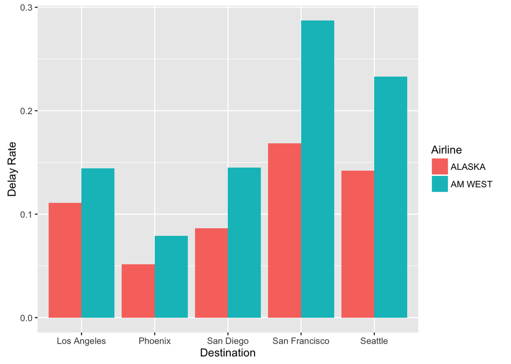

```r
ggplot(delays, aes(Destination, Delay_Rate)) +
  geom_bar(aes(fill = Airline), position = "dodge", stat = "identity") +
  ylab("Delay Rate")
```

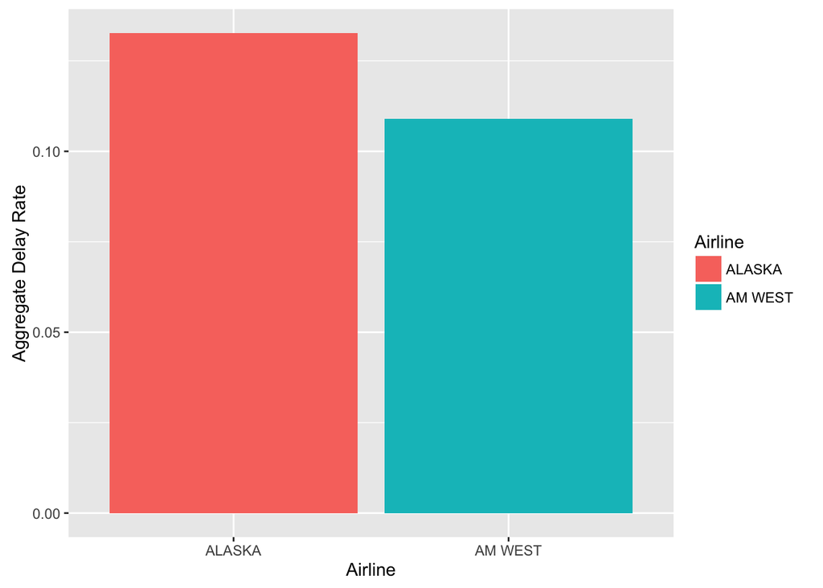

```r
ggplot(agg_dly_rate, aes(Airline, Agg_Dly_Rate)) +
  geom_bar(aes(fill = Airline), position = "dodge", stat = "identity") +
  ylab("Aggregate Delay Rate")
```

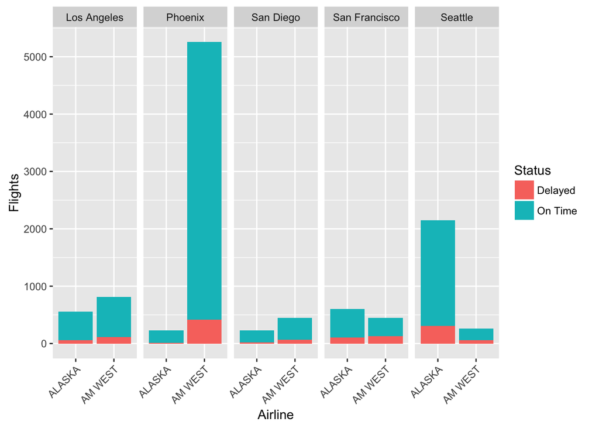

```r
delays_gathered <- delays %>% gather(Status, Flights, Delayed, On_Time)

ggplot(delays_gathered, aes(x = Airline, y = Flights, fill = Status)) +
  geom_bar(position = "stack", stat = "identity") + facet_grid(~ Destination) +
  theme(axis.text.x = element_text(angle = 45, hjust = 1)) +
  scale_fill_discrete(labels = c("Delayed", "On Time"))
```

#### Sources

Fung, Kaiser (2013). *Numbersense: How to Use Big Data to Your Advantage*. McGraw-Hill: 1-15.

- Our data for this week’s assignment come from Fung’s *Numbersense*. In the book’s prologue, Fung shows how the flight delay data manifest Simpson’s paradox, and reminds readers to pay close attention to the ways that different methods of aggregation and analysis can produce conflicting interpretations of the same data.

Wickham, Hadley (2014). Tidy Data. *Journal of Statistical Software*, 59(10).